# Community Transformation Map: Wave 3

The SCALE Evaluation Team

January 14, 2019

# How do we facilitate **Community Transformation?**

The **[Community Transformation Map](https://www.dropbox.com/s/9sgdbwo84chc0gy/Community-Transformation-Map-Final-9-1-17.pdf?dl=0)** is a hybrid tool/assessment that is used by the SCALE communities to assess current progress on Community of Solution skills and to make decisions about how to proceed with continued capacity development. The CTM draws from two primary sources: the SCALE theory of change and the R=MC<sup>2</sup> model of readiness. R=MC<sup>2</sup> says that readiness is a function of motivation, innovation-specific capacity, and general capacity.

Items in the CTM are designed to measure capacities and motivations that are needed into to engage in a community transformation process. Each item is specified via a qualitative description, which describes different levels of an innovation ranging from having no skill, to being able to spread and teach others. This framing helps to anchor the scale in specific descriptions and illustrates what implementation of a particular skill looks like in practice.

Click on the below tabs to explore the data at your own pace.

## Overall Changes

This first set of graphs visualize overall progress on the three different categories of the CTM: *How the communities approach change*, *how the communities relate to one another and create abundance*, and *how the communities approach change equity over time*.

We aggregrate the items in each of these categories in order to simply the visuals, though full results are available upon request. The below three figures show *density plots* across the three timepoints. A density plot is a smoothed distribution of scores across all communities (similar to a histogram). Because the top curve for the most recent timepoint is furthest to the right, we can see that overall communities have progressed over the past year.

### How the Communities approach change.

This set of items look at how community develop a change vision, co-design interventions and strategies with community stakeholders, apply methods grounded in improvement science, expressing an openness to using changes from others, and working toward sustainability.

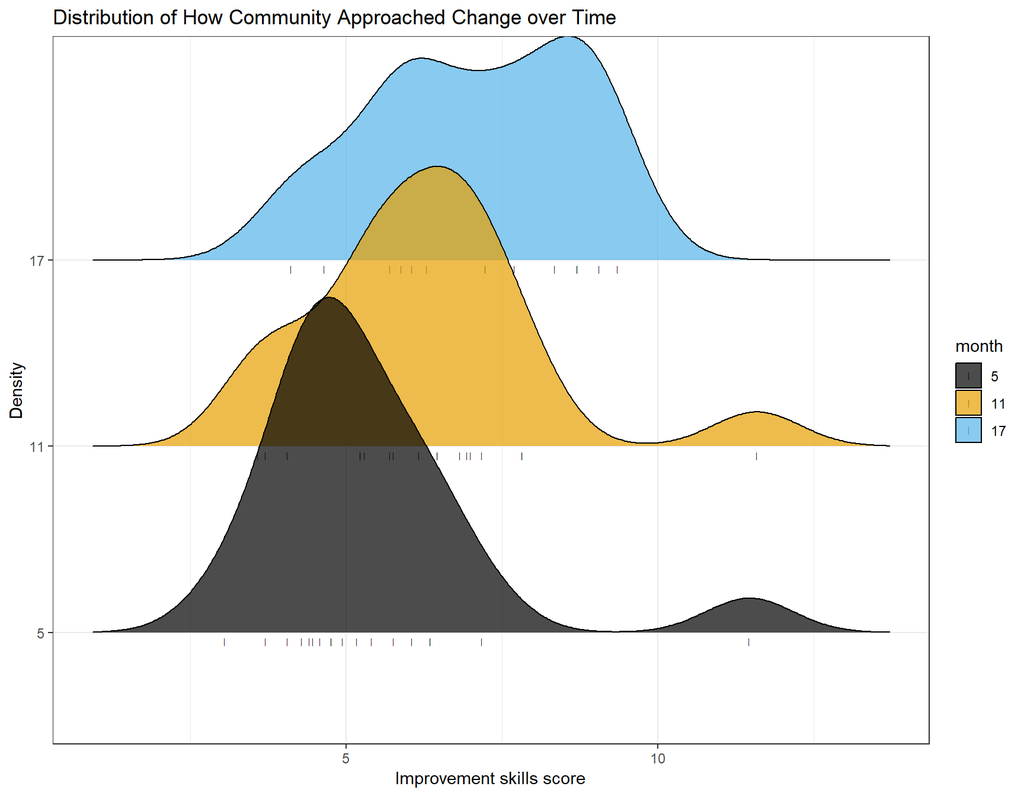

### How the Communities Relate to One Another and Create Abundance.

This set of items look at the underlying organizationa process of the community collaboration, how they communicate with one another, how they resolve conflict, whether there is a sense of shared stewardship, and how they collaborate with other partners.

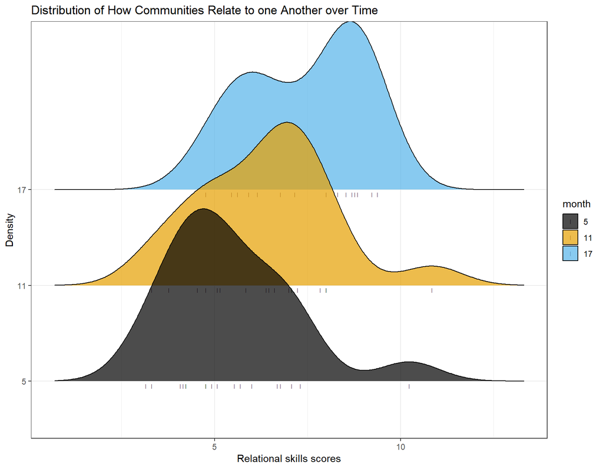

### How the Communities Lead for Social Change and Equity.

Finally, this group of items assess how communities grow the leadership of those affected by inequity, distribute leadership across multiple stakeholders, and take effective action to improve equity,

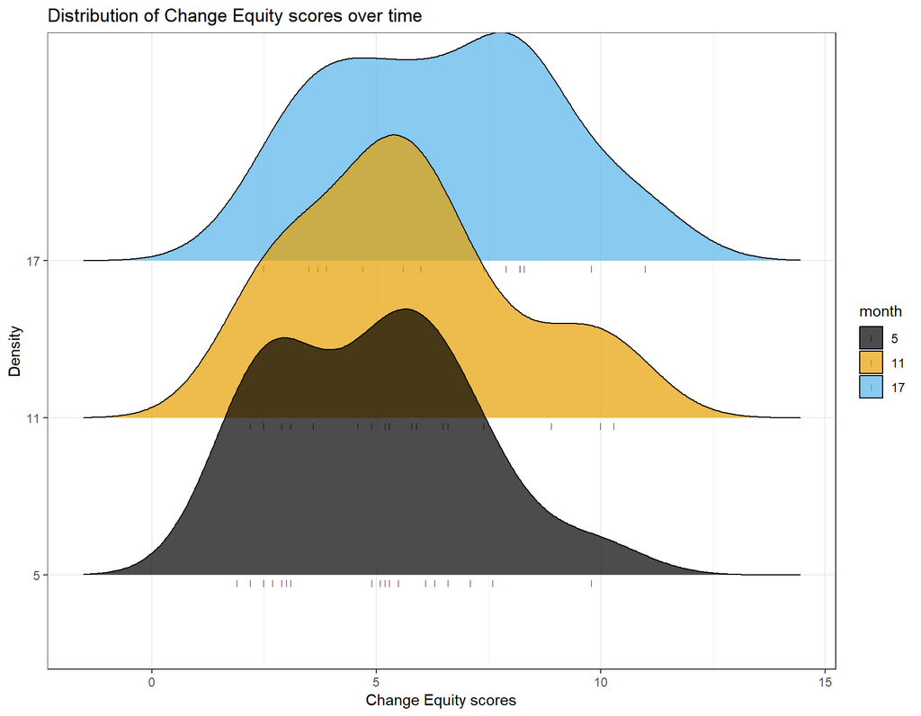

The below plots show community by community change over time. These graphs are not ideal because they are crowded (they are colloquially known as spaghetti plots). However, they do show that there is variation in progress made over time from September 2017 to September 2018. We note that because not all communities completed their Wave 3 data, there are gaps in their progress. We also can see that some communities regressed, but have rebounded.

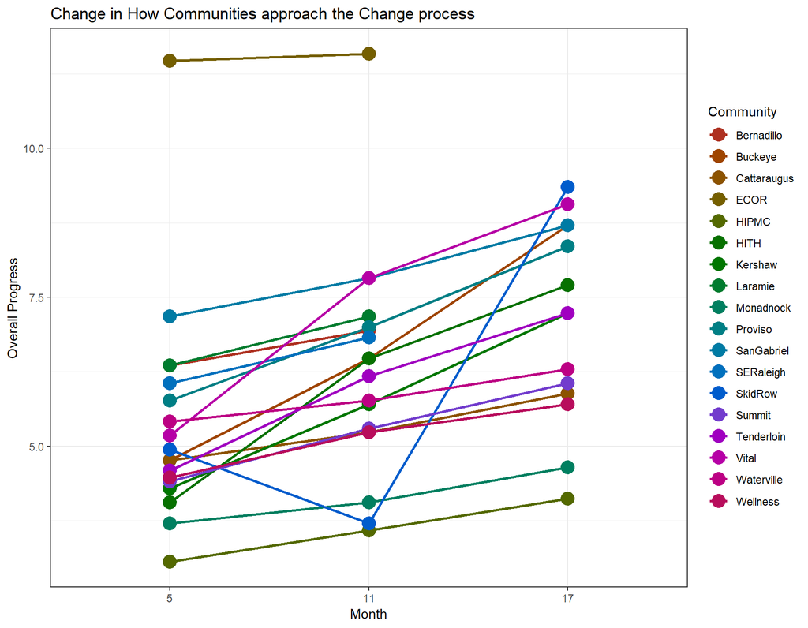

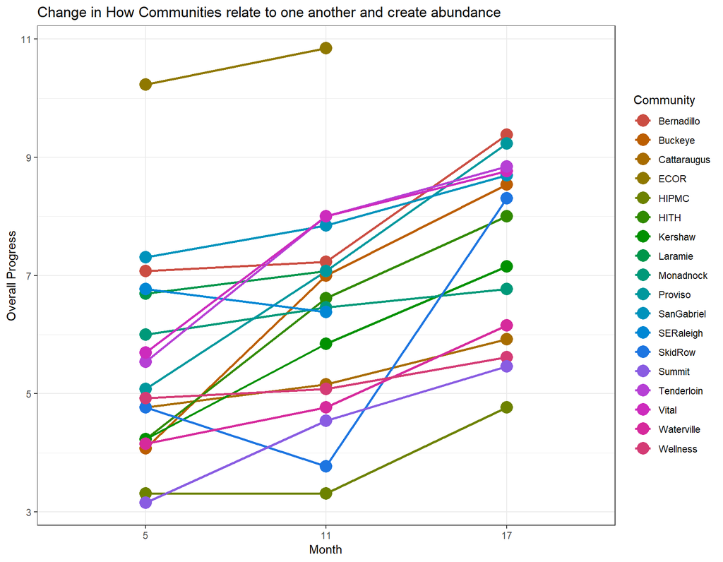

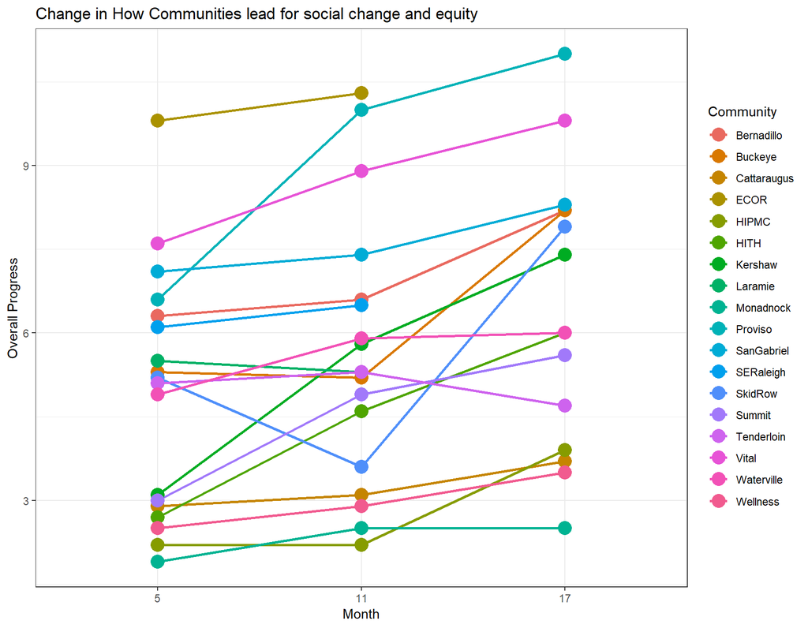

## Growth across categories

Now let’s look at a different type of visualization that show how communities have changed over time, within the three different categories in the CTM. Like above, if a community did not complete their Wave 3 data, there is a gap in their overall findings. In this figure, we see how communities have progressed in how they approach change. The length of the line is indicative of a larger amount of reported progress. The coordinating numbers refer to timepoint.

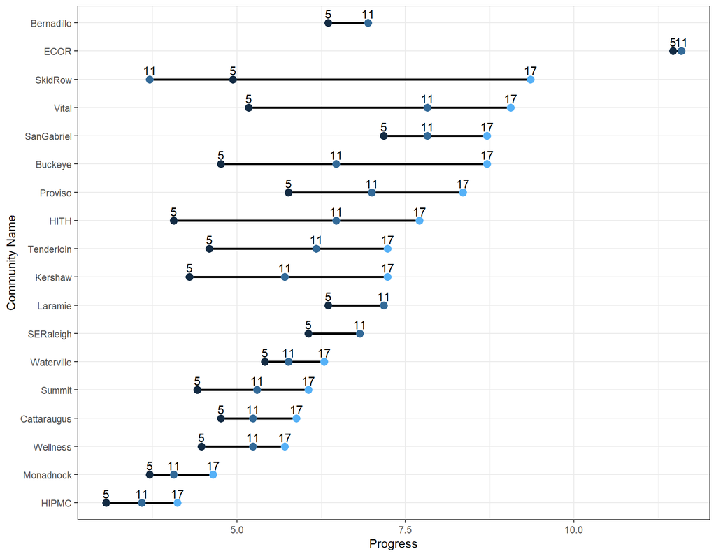

This figure shows how communities have progress in how communities the relate to one another and create abundance.

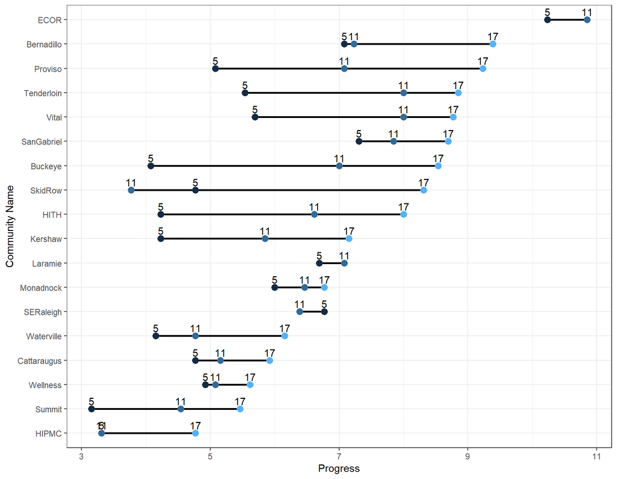

Finally, this figure shows how communities have progressed in how they lead for social change and equity.

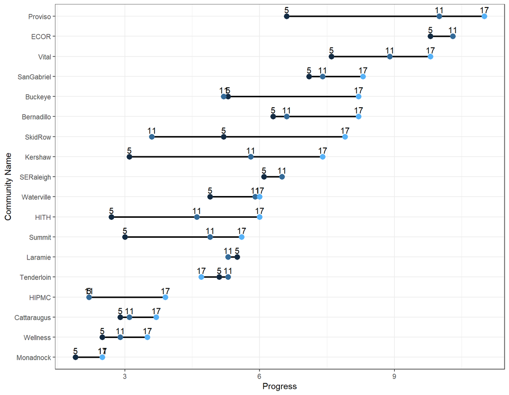

## Relationships between factors

This last series of plots look at the interrationships/correlations between these factors across all three timepoints.

The first series of figures here are correlation plots. They show the how each variable or item varied with each other. The color coding shows the strength of the relationship. *Note:* we were only able to produce these matrics for September 2017. This is because not all communities completed all parts at different timepoints.

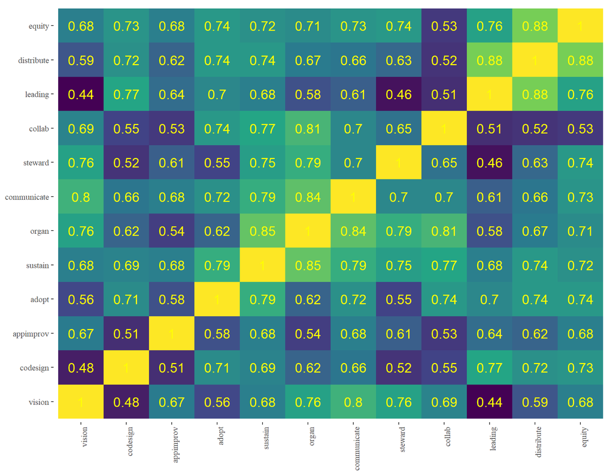

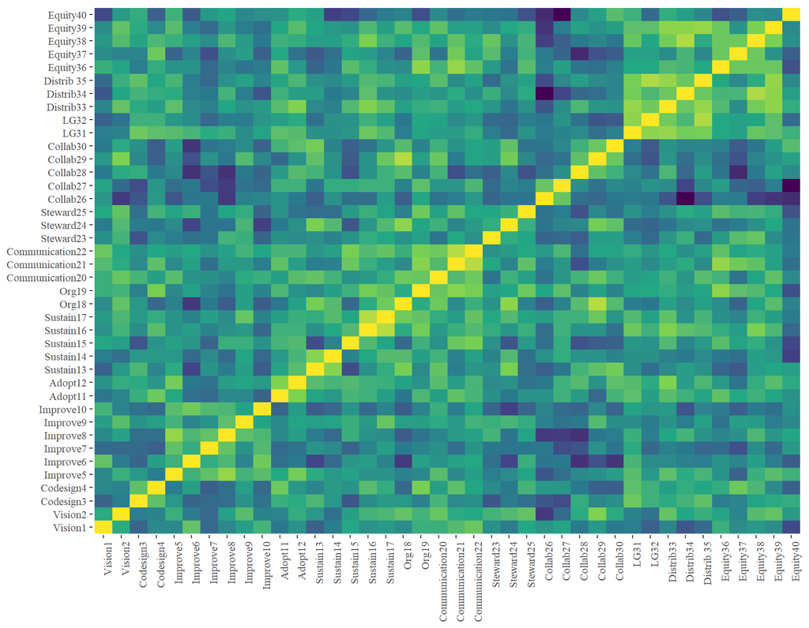

Finally, we looked at the relationship between the top level sections of the CTM. We see that the relationships has been generally consistent over time, suggesting that progress being made in one area corresponds to progress in another. This is also consistent with the SCALE theory of change that suggests all three areas are needed to work toward community transformation.

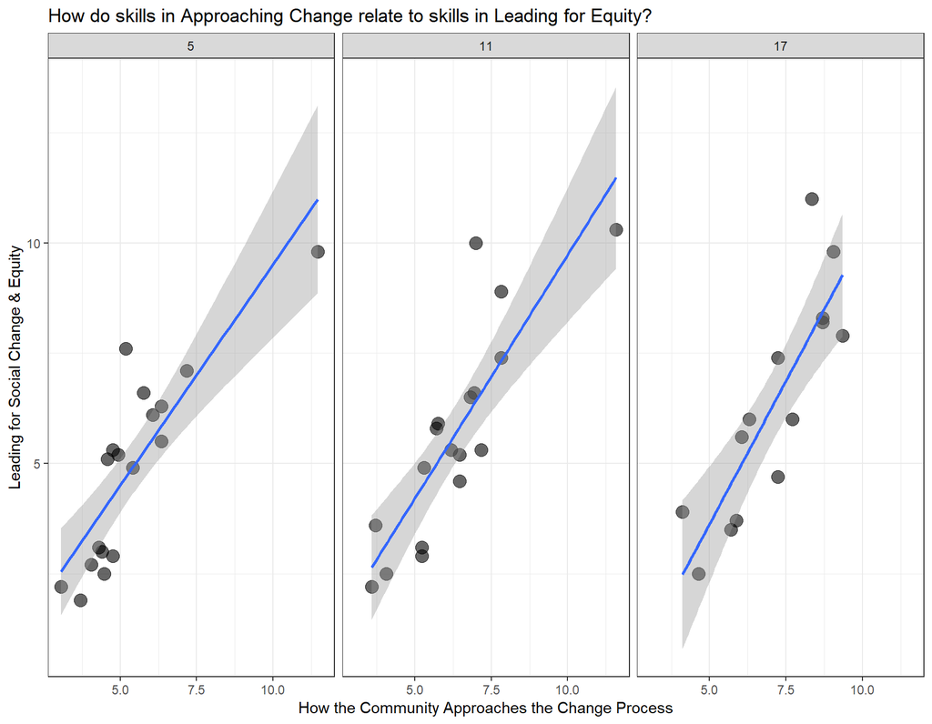

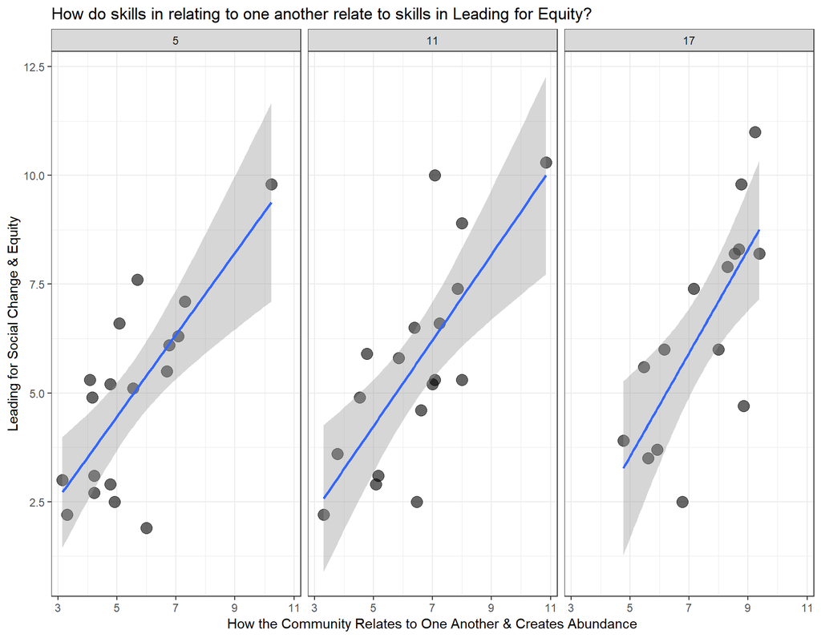

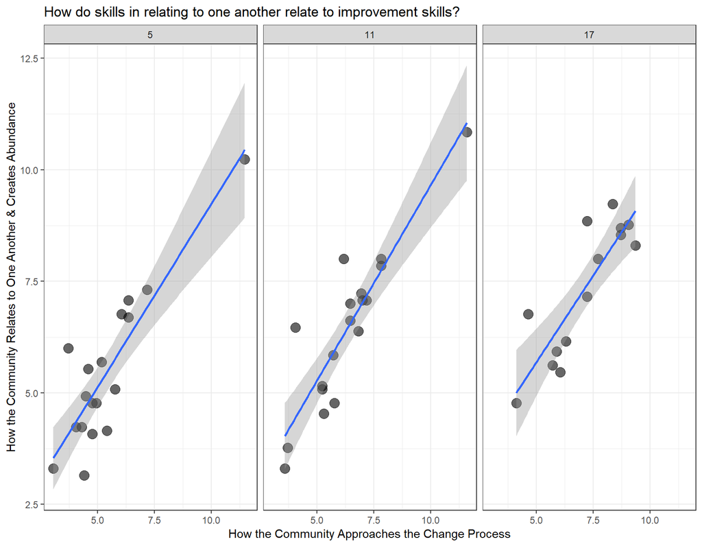

## Expanding use of Transformation Maps

We have begun to apply a similiar structure for assessing readiness for transformation across 100 Million Healthier Live. To date, we have developed transformation maps for States of Solution and SCALE Health and Care’s *Pathways to Population Health*. We are currently developing a tool focused exclusively on address racial disparties. Our plan is to develop a comprehesive evaluation plan that synthesizes key items that are linked to progress.

For more information about SCALE and this project, visit [100 Million Healthier Lives.](https://www.100mlives.org/) For more information about Readiness, visit [The Wandersman Center.](https://www.wandersmancenter.com/)

[figure not shown]

This work is licensed under a [Creative Commons Attribution-NonCommercial-NoDerivatives 4.0 International License](http://creativecommons.org/licenses/by-nc-nd/4.0/).